# Homework 2

## EX1

In this exercise I wanted to rank the following functions by their order of growth. The functions are: 2lg*n, n3, lg*n, en, n, n2, lg(n!), 2n, n!, 22^n, ln(n), (n + 1)!, nlg(n), 1, 22^(n+1)

### Conclusions:

> Based on the plot above the O(1) is the best then O(ln) then O(lg*n) then O(n) then O(nlogn) then O(2lg*n) then O(lg(n!)) then O(n^2) then O(n^3) then O(2^n) then O(2^2^n) then O(2^2^(n+1)) then O(n!) O(e^n) then O((n + 1)!)

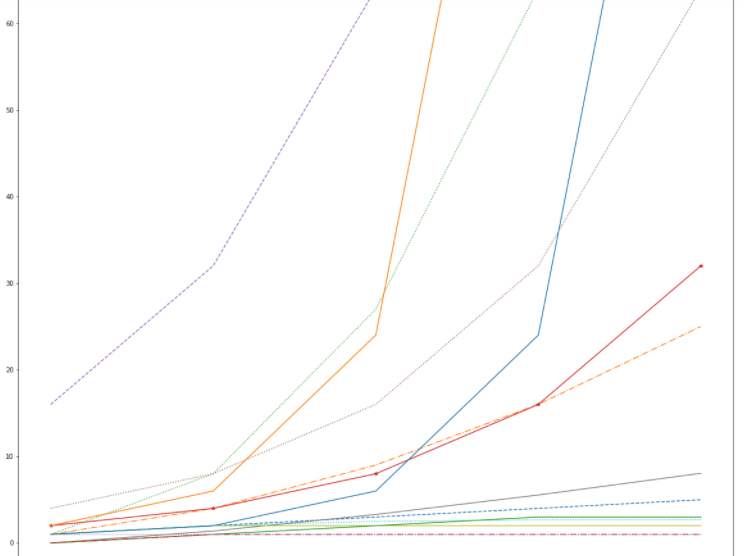

```python
from PIL import Image
Image.open("3.PNG")
```

The plot is more visable in the notebook

## EX2

In this exercise I wanted to visually compare growth rates of functions (at least 8) from the above exercise.

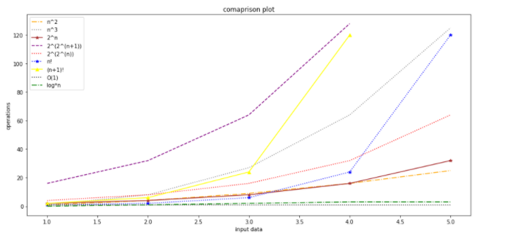

```python
Image.open("4.PNG")
```

### Conclusions:

- I can avoid flatten the plot by correctly implementing the functions and choosing the right values to plot.
- We can actually see the order is a bit different on the small values but I have implemented the above plots on larger values and the order was right. First we have the O(1) THEN the O(log*n) then O(n^2) then O(2^n) then O(n!) then O(2^(2^(n))) then O(n^3) then O((n+1)!) and finally O(2^(2^(n+1)))

### EX3: Part 1

In this exercise I wanted to Draw a recursion tree for recurrences for the following algorithms:

- A(N) = A(N/2) + 1
- B(N) = 2B(N/2) + N

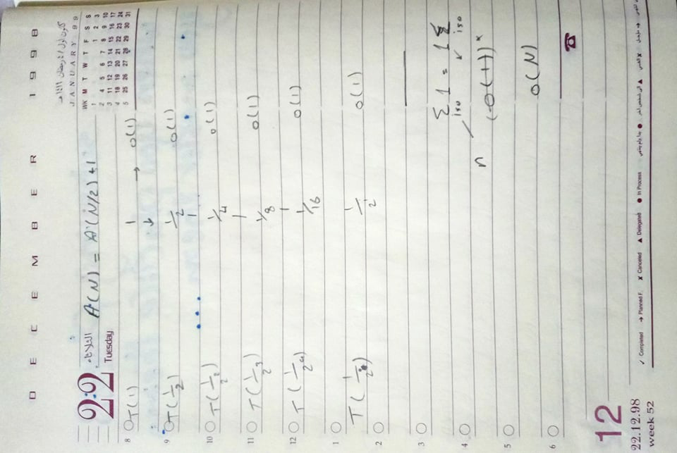

```python
Image.open("2.jpg")
```

I draw the recursion tree for the first function: A(N) = A(N/2) + 1.

[figure not shown]

```python
Image.open("2new.jpg")
```

### EX3: Part 2

In this section I want to estimate the number of operations.

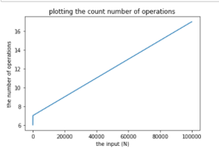

```python
Image.open("5.PNG")
```

### Conclusions:

> By the above gragh we can actually see that the operation number increases when we increase the input (n). but we can also see the small slope of the line. it equals 0.0001 meanwhile the intercept is relatively high equals 6.49

### EX4

In this excerise we will implement the linear search alogrithms and the binary search algorithms. I read the data, then I implemented the linear search alogrithm, then created a callback function to output a better more meaningful results. then I tested the linear search implementation on both the existing words and non-existing words.

In this exercise I also implemented the above steps for the binary search algorithm.

### EX5

In this exercise we will finally plot the runtime of both the linear and binary search on both the existing and non-existing words. I plotted each one alone but in order to get more clarity I plotted each two sets together(The linear and binary search runtime for the existing words) and the (linear and binary search runtime for the non-existing words).

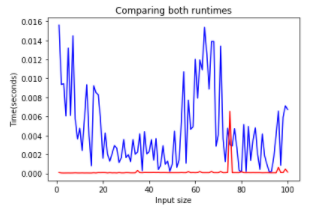

```python
Image.open("comp1.PNG")
```

In this plot we can actually see the binary search runtime (red line) is much much faster than the binary search.

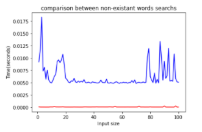

```python
Image.open("comp2.PNG")
```

In this plot we can actually see the binary search runtime (red line) is much much faster than the binary search.

### From the above two plots we can actually see that the binary search is much faster than the linear search.